# Moran’s I rescaling

Ivan Fuentes, Thomas Dewiit, Thomas Ioerger, Michael Bishop

2019-11-21

Many Geographical Analysis utilizes spatial autocorrelation, that allows us to study the geographical evolution from different points of view. One measurement for spatial autocorrelation is Moran’s I, that is based on Pearson’s correlation coefficient in general statistics (Chen 2013)

## Performing the Analysis

This package offers two ways to rectify Moran’s I. The first method is a Procrustes method, and the second one is a rectifying through Pearson correlation. We provided a straight forward way to perform both techniques.

### Rectification method 1. Three-point anisometric scaling (3-PAS)

The package offers, as stated before, a direct way to apply the Procrustes technique to a data set. The function `rescaleI` requires an input file path, the number of samples to create the null distribution, and a parameter that establishes up to which value the Moran’s I value will be stretch.

The Loading data section explains the required format of the input file. The parameter `scalingUpTo` accepts two string values, “MaxMin” and “Quantile.” The first value is self-explanatory, while the second one refers to the quantiles 0.1% and 99.99%. The default value is “Quantile”, meaning that, if something different to “MaxMin” or “Quantile” is sent, the `iCorrection` function will apply “Quantile”.

```r
library(Irescale)
fileInput<-system.file("testdata", "chen.csv", package="Irescale")
data<-loadFile(fileInput)
scaledI<-rescaleI(data,samples=1000, scalingUpTo="MaxMin")
```

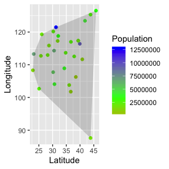

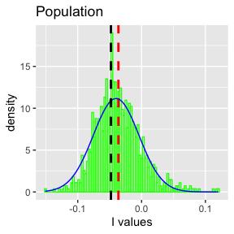

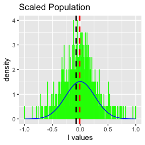

```r
fn = file.path(tempdir(),"output.csv",fsep = .Platform$file.sep)
saveFile(fn,scaledI)
if (file.exists(fn))
  #Delete file if it exists
  file.remove(fn)
```

```
#> [1] TRUE
```

### Rectified Correlation

```r
fileInput <- system.file("testdata", "chen.csv", package="Irescale")
data <- loadFile(fileInput)
rectifiedI<-rectifyIrho(data,1000)
```

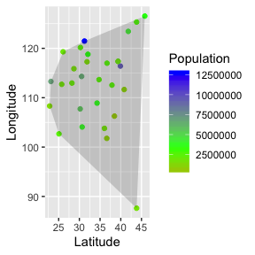

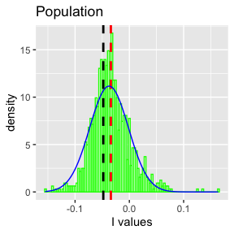

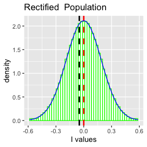

```r
fn = file.path(tempdir(),"output.csv",fsep = .Platform$file.sep)
saveFile(fn,rectifiedI)
if (file.exists(fn))
  #Delete file if it exists
  file.remove(fn)
```

```
#> [1] TRUE
```

## Analysis Step by Step

The method rescaleI is a wrap for a pipeline that can be executed step by step.

### Loading data

The input file[^1] should have the following format.

- The first column represents an unique id for the record.
- The second and third column represent the latitute and longitud of where the sample was taken
- The fourth and beyond represents the different measured variables

```r
fileInput<-system.file("testdata", "chen.csv", package="Irescale")
head(read.csv(fileInput))
```

```
#>           City Latitude Longitude Population
#> 1      Beijing 39.90420  116.4074    9496688
#> 2      Tianjin 39.34336  117.3616    5313702
#> 3 Shijiazhuang 39.34336  117.3616    1930579
#> 4      Taiyuan 37.87059  112.5489    2538336
#> 5      Hohehot 40.82192  111.6581     990954
#> 6     Shenyang 41.80570  123.4315    4344933
```

To load data to performe the analysis is quite simple. The function `loadFile` provides the interface to make it. loadFile returns a list with two variables, `data` and `varOfInterest`, the first one represents a vector with latitude and longitude; `varOfInterest` is a matrix with all the measurements from the field.

```r
library(Irescale)
fileInput<-system.file("testdata", "chen.csv", package="Irescale")
input<-loadFile(fileInput)
head(input$data)
```

```
#>              Latitude Longitude
#> Beijing      39.90420  116.4074
#> Tianjin      39.34336  117.3616
#> Shijiazhuang 39.34336  117.3616
#> Taiyuan      37.87059  112.5489
#> Hohehot      40.82192  111.6581
#> Shenyang     41.80570  123.4315
```

```r
head(input$varOfInterest)
```

```
#>              Population
#> Beijing         9496688
#> Tianjin         5313702
#> Shijiazhuang    1930579
#> Taiyuan         2538336
#> Hohehot          990954
#> Shenyang        4344933
```

If the data has a chessboard shape,the file is organized in rows and columns, where the rows represent latitute and columns longitude, the measurements are in the cell. The function `loadChessBoard` can be used to load into the analysis.

```r
library(Irescale)
fileInput<-"../inst/testdata/chessboard.csv"
input<-loadChessBoard(fileInput)
head(input$data)
```

```
#>      [,1] [,2]
#> [1,]    1    1
#> [2,]    1    2
#> [3,]    1    3
#> [4,]    1    4
#> [5,]    1    5
#> [6,]    1    6
```

```r
head(input$varOfInterest)
```

```
#> [1] 1 1 1 1 1 1
```

### Calculate Distance

Once the data is loaded, The distance matrix, the distance between all the points might be calcualted. The distance can be calculated using `calculateEuclideanDistance’ if the points are taken in a geospatial location.

```r
library(Irescale)
fileInput<-system.file("testdata", "chen.csv", package="Irescale")
input<-loadFile(fileInput)
distM<-calculateEuclideanDistance(input$data)
distM[1:5,1:5]
```

```
#>          [,1]     [,2]     [,3]     [,4]     [,5]
#> [1,] 0.000000 1.106865 1.106865 4.361616 4.837197
#> [2,] 1.106865 0.000000 0.000000 5.033068 5.892130
#> [3,] 1.106865 0.000000 0.000000 5.033068 5.892130
#> [4,] 4.361616 5.033068 5.033068 0.000000 3.082845
#> [5,] 4.837197 5.892130 5.892130 3.082845 0.000000
```

If the data is taken from a chessboard a like field, the Manhattan distance can be used.

```r
library(Irescale)
fileInput<-"../inst/testdata/chessboard.csv"
input<-loadChessBoard(fileInput)
distM<-calculateManhattanDistance(input$data)
distM[1:5,1:5]
```

```
#>      [,1] [,2] [,3] [,4] [,5]
#> [1,]    0    1    2    3    4
#> [2,]    1    0    1    2    3
#> [3,]    2    1    0    1    2
#> [4,]    3    2    1    0    1
#> [5,]    4    3    2    1    0
```

### Calculate Weighted Distance Matrix

The weighted distance matrix can be calculated it using the function `calculateWeightedDistMatrix`, however it is not required to do it, because ‘calculateMoranI’ does it.

```r
library(Irescale)
fileInput<-system.file("testdata", "chen.csv", package="Irescale")
input<-loadFile(fileInput)
distM<-calculateEuclideanDistance(input$data)
distW<-calculateWeightedDistMatrix(distM)
distW[1:5,1:5]
```

```
#>             [,1]        [,2]        [,3]        [,4]        [,5]
#> [1,] 0.000000000 0.009745774 0.009745774 0.002473224 0.002230063
#> [2,] 0.009745774 0.000000000 0.000000000 0.002143276 0.001830791
#> [3,] 0.009745774 0.000000000 0.000000000 0.002143276 0.001830791
#> [4,] 0.002473224 0.002143276 0.002143276 0.000000000 0.003499124
#> [5,] 0.002230063 0.001830791 0.001830791 0.003499124 0.000000000
```

### Moran’s I

It is time to calculate the spatial autocorrelation statistic Morans’ I. The function `calcualteMoranI`, which requires the distance matrix, and the variable you want are interested on.

```r
library(Irescale)
fileInput<-system.file("testdata", "chen.csv", package="Irescale")
input<-loadFile(fileInput)
distM<-calculateEuclideanDistance(input$data)
I<-calculateMoranI(distM = distM,varOfInterest = input$varOfInterest)
I
```

```
#> [1] -0.04800907
```

### Resampling Method for I

The scaling process is made using Monte Carlo resampling method. The idea is to shuffle the values and recalculate I for at least 1000 times. In the code below, after resampling the value of I, a set of statistics are calculated for that generated vector.

```r
library(Irescale)
fileInput<-system.file("testdata", "chen.csv", package="Irescale")
input<-loadFile(fileInput)
distM<-calculateEuclideanDistance(input$data)
I<-calculateMoranI(distM = distM,varOfInterest = input$varOfInterest)
vI<-resamplingI(distM, input$varOfInterest) # This is the permutation
statsVI<-summaryVector(vI)
statsVI
```

```
#> $mean
#> [1] -0.03531522
#>
#> $sd
#> [1] 0.03654939
#>
#> $max
#> [1] 0.2290524
#>
#> $min
#> [1] -0.1350819
#>
#> $Q1
#>       0.1%
#> -0.1321211
#>
#> $Q99
#>    99.99%
#> 0.2208389
#>
#> $median
#> [1] -0.03868094
#>
#> $skew
#> [1] 1.009807
#>
#> $kurt
#> [1] 3.973344
```

#### Plotting Distribution (Optional)

To see how the value of I is distribuited, the method `plotHistogramOverlayNormal` provides the functionality to get a histogram of the vector generated by resampling with a theorical normal distribution overlay.

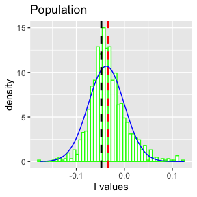

```r
library(Irescale)
fileInput<-system.file("testdata", "chen.csv", package="Irescale")
input<-loadFile(fileInput)
distM<-calculateEuclideanDistance(input$data)
I<-calculateMoranI(distM = distM,varOfInterest = input$varOfInterest)
vI<-resamplingI(distM, input$varOfInterest) # This is the permutation
statsVI<-summaryVector(vI)
plotHistogramOverlayNormal(vI,statsVI, main=colnames(input$varOfInterest))
```

### Rectifying I

Once we have calculated the null distribution via resampling, you need to scale by centering and streching. The method `iCorrection`, return an object with the resampling vector rescaled, and all the summary for this vector, the new value of I is returned in a variable named `newI`

#### Rectification method 1. Three-point anisometric scaling (3-PAS)

As a reminder there are two ways to rectify I, in this section we present the procrustes methodology.

```r
library(Irescale)
fileInput<-system.file("testdata", "chen.csv", package="Irescale")
input<-loadFile(fileInput)
distM<-calculateEuclideanDistance(input$data)
I<-calculateMoranI(distM = distM,varOfInterest = input$varOfInterest)
vI<-resamplingI(distM, input$varOfInterest) # This is the permutation
statsVI<-summaryVector(vI)
corrections<-iCorrection(I,vI)
corrections$newI
```

```
#>       0.1%
#> -0.1050817
```

#### Rectification method 2. Pearson Correlation

```r
fileInput <- system.file("testdata", "chen.csv", package="Irescale")
data <- loadFile(fileInput)
distM<-calculateEuclideanDistance(data$data)
vI<-resamplingI(distM,data$varOfInterest,n = 100000)
rectifiedI<- ItoPearsonCorrelation(vI, length(data))
rectifiedI$newI
```

```
#> [1] -0.3301686
```

## Calculate P-value

In order to provide a significance to this new value, you can calculate the pvalue using the method `calculatePvalue`. This method requires the scaled vector, you get this vector,`scaledData`, the scaled I, `newI` and the mean of the `scaledData`.

```r
library(Irescale)
fileInput<-system.file("testdata", "chen.csv", package="Irescale")
input<-loadFile(fileInput)
distM<-calculateEuclideanDistance(input$data)
I<-calculateMoranI(distM = distM,varOfInterest = input$varOfInterest)
vI<-resamplingI(distM, input$varOfInterest) # This is the permutation
statsVI<-summaryVector(vI)
corrections<-iCorrection(I,vI)
pvalueIscaled<-calculatePvalue(corrections$scaledData,corrections$newI,corrections$summaryScaledD$mean)
pvalueIscaled
```

```
#> [1] 0.3606394
```

## Stability Analysis

```
#> [1] 29
```

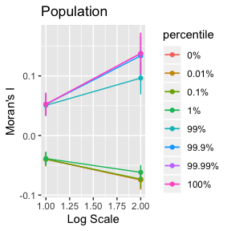

```r
library(Irescale)
fileInput<-system.file("testdata", "chen.csv", package="Irescale")
input<-loadFile(fileInput)
resultsChen<-buildStabilityTable(data=input, times=10, samples=10^2, plots=TRUE)
```

### Rectifying with correlation

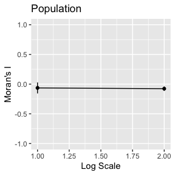

```r
fileInput <- system.file("testdata", "chen.csv", package="Irescale")
data <- loadFile(fileInput)
resultsChen<-buildStabilityTableForCorrelation(data=data,times=10,samples=10^2,plots=TRUE)
```

# References

Chen, Yanguang. 2013. “New Approaches for Calculating Moran’s Index of Spatial Autocorrelation.” *PloS One* 8 (7). Public Library of Science: e68336.

[^1]: The data used in this example is taken from (Chen 2013).